# Employee Turnover Prediction

This notebook provides an example of analyze data for prediction employee turnover. By preprocessing data and feed that into models using Machine Learning, we can predict if one person will leave the company based on factors like salary, working hours and years at company.

```python
# data analysis and wrangling
import pandas as pd
import numpy as np
import random as rnd

# visualization
import seaborn as sns
import matplotlib.pyplot as plt
%matplotlib inline

# machine learning
from sklearn.linear_model import LogisticRegression
from sklearn.svm import SVC, LinearSVC
from sklearn.ensemble import RandomForestClassifier
from sklearn.neighbors import KNeighborsClassifier
from sklearn.naive_bayes import GaussianNB
from sklearn.linear_model import Perceptron
from sklearn.linear_model import SGDClassifier
from sklearn.tree import DecisionTreeClassifier
```

```python
df = pd.read_csv('HR_comma_sep.csv')
```

```python
import tensorflow as tf
```

```python
node1 = tf.constant(3.0, dtype=tf.float32)
node2 = tf.constant(4.0) # also tf.float32 implicitly
print(node1, node2)
```

```
tf.Tensor(3.0, shape=(), dtype=float32) tf.Tensor(4.0, shape=(), dtype=float32)
```

```python
# Describe data to Analyze
print(df.columns.values)
```

```
['satisfaction_level' 'last_evaluation' 'number_project'
 'average_montly_hours' 'time_spend_company' 'Work_accident' 'left'
 'promotion_last_5years' 'sales' 'salary']
```

```python
# Analyze the distribution of numerical feature values
df.describe()
```

|  | satisfaction_level | last_evaluation | number_project | average_montly_hours | time_spend_company | Work_accident | left | promotion_last_5years |
| --- | --- | --- | --- | --- | --- | --- | --- | --- |
| count | 14999.000000 | 14999.000000 | 14999.000000 | 14999.000000 | 14999.000000 | 14999.000000 | 14999.000000 | 14999.000000 |
| mean | 0.612834 | 0.716102 | 3.803054 | 201.050337 | 3.498233 | 0.144610 | 0.238083 | 0.021268 |
| std | 0.248631 | 0.171169 | 1.232592 | 49.943099 | 1.460136 | 0.351719 | 0.425924 | 0.144281 |
| min | 0.090000 | 0.360000 | 2.000000 | 96.000000 | 2.000000 | 0.000000 | 0.000000 | 0.000000 |
| 25% | 0.440000 | 0.560000 | 3.000000 | 156.000000 | 3.000000 | 0.000000 | 0.000000 | 0.000000 |
| 50% | 0.640000 | 0.720000 | 4.000000 | 200.000000 | 3.000000 | 0.000000 | 0.000000 | 0.000000 |
| 75% | 0.820000 | 0.870000 | 5.000000 | 245.000000 | 4.000000 | 0.000000 | 0.000000 | 0.000000 |
| max | 1.000000 | 1.000000 | 7.000000 | 310.000000 | 10.000000 | 1.000000 | 1.000000 | 1.000000 |

```python
# Preview the data
df.head()
```

|  | satisfaction_level | last_evaluation | number_project | average_montly_hours | time_spend_company | Work_accident | left | promotion_last_5years | sales | salary |
| --- | --- | --- | --- | --- | --- | --- | --- | --- | --- | --- |
| 0 | 0.38 | 0.53 | 2 | 157 | 3 | 0 | 1 | 0 | sales | low |
| 1 | 0.80 | 0.86 | 5 | 262 | 6 | 0 | 1 | 0 | sales | medium |
| 2 | 0.11 | 0.88 | 7 | 272 | 4 | 0 | 1 | 0 | sales | medium |
| 3 | 0.72 | 0.87 | 5 | 223 | 5 | 0 | 1 | 0 | sales | low |
| 4 | 0.37 | 0.52 | 2 | 159 | 3 | 0 | 1 | 0 | sales | low |

# Check for missing data

By checking if there is any missing data, we see we luckly don't have any. Therefore no action is needed to fill in the null blanks.

```python
df.isnull().any()
```

```
satisfaction_level       False
last_evaluation          False
number_project           False
average_montly_hours     False
time_spend_company       False
Work_accident            False
left                     False
promotion_last_5years    False
sales                    False
salary                   False
dtype: bool
```

# Cast categorical data type to numerical

By showing the info of dataset, we see sales and salary are categorical data type, that will need conversion later.

```python
df.info()
```

```
<class 'pandas.core.frame.DataFrame'>
RangeIndex: 14999 entries, 0 to 14998
Data columns (total 10 columns):
 #   Column                 Non-Null Count  Dtype
---  ------                 --------------  -----
 0   satisfaction_level     14999 non-null  float64
 1   last_evaluation        14999 non-null  float64
 2   number_project         14999 non-null  int64
 3   average_montly_hours   14999 non-null  int64
 4   time_spend_company     14999 non-null  int64
 5   Work_accident          14999 non-null  int64
 6   left                   14999 non-null  int64
 7   promotion_last_5years  14999 non-null  int64
 8   sales                  14999 non-null  object
 9   salary                 14999 non-null  object
dtypes: float64(2), int64(6), object(2)
memory usage: 1.1+ MB
```

Now check the distribution of Categorical features

```python
df.describe(include=['O'])
```

|  | sales | salary |
| --- | --- | --- |
| count | 14999 | 14999 |
| unique | 10 | 3 |
| top | sales | low |
| freq | 4140 | 7316 |

Sales has 10 ranges and salary has 3 ranges. This will be helpful when we convert the data to numerical features

```python
df['salary'] = df['salary'].map( {'high':2 ,'medium': 1, 'low':
0} ).astype(int)
df.head()
```

|  | satisfaction_level | last_evaluation | number_project | average_montly_hours | time_spend_company | Work_accident | left | promotion_last_5years | sales | salary |
| --- | --- | --- | --- | --- | --- | --- | --- | --- | --- | --- |
| 0 | 0.38 | 0.53 | 2 | 157 | 3 | 0 | 1 | 0 | sales | 0 |
| 1 | 0.80 | 0.86 | 5 | 262 | 6 | 0 | 1 | 0 | sales | 1 |
| 2 | 0.11 | 0.88 | 7 | 272 | 4 | 0 | 1 | 0 | sales | 1 |
| 3 | 0.72 | 0.87 | 5 | 223 | 5 | 0 | 1 | 0 | sales | 0 |
| 4 | 0.37 | 0.52 | 2 | 159 | 3 | 0 | 1 | 0 | sales | 0 |

Now let's look at how we can convert "sales" variable to number. First we need to know what are the ten types "sales" has, since it is not obvious at the head of dataset.

```python
old = []
for obj in df['sales']:
    if obj not in old:
        print(obj)
        old.append(obj)
```

```
sales
accounting
hr
technical
support
management
IT
product_mng
marketing
RandD
```

From this for loop, we know there are ten types of sales: sales, accounting, hr, technical, support, IT, management , product_mng, marketing, RandD. We can now map all of job titles to numbers.

```python
df['sales'] = df['sales'].map( {'sales':9 , 'accounting':8 , 'hr':7,
'technical':6, 'support':5, 'management':4, 'IT':3,
'product_mng':2, 'marketing':1, 'RandD':0} ).astype(float)
df.head()
```

|  | satisfaction_level | last_evaluation | number_project | average_montly_hours | time_spend_company | Work_accident | left | promotion_last_5years | sales | salary |
| --- | --- | --- | --- | --- | --- | --- | --- | --- | --- | --- |
| 0 | 0.38 | 0.53 | 2 | 157 | 3 | 0 | 1 | 0 | 9.0 | 0 |
| 1 | 0.80 | 0.86 | 5 | 262 | 6 | 0 | 1 | 0 | 9.0 | 1 |
| 2 | 0.11 | 0.88 | 7 | 272 | 4 | 0 | 1 | 0 | 9.0 | 1 |
| 3 | 0.72 | 0.87 | 5 | 223 | 5 | 0 | 1 | 0 | 9.0 | 0 |
| 4 | 0.37 | 0.52 | 2 | 159 | 3 | 0 | 1 | 0 | 9.0 | 0 |

# Find correlation of data and leaving rate

|  | satisfaction_level | last_evaluation | number_project | average_montly_hours | time_spend_company | Work_accident | left | promotion_last_5years | sales | salary |
| --- | --- | --- | --- | --- | --- | --- | --- | --- | --- | --- |
| satisfaction_level | 1.000000 | 0.105021 | -0.142970 | -0.020048 | -0.100866 | 0.058697 | -0.388375 | 0.025605 | -0.015413 | 0.050022 |
| last_evaluation | 0.105021 | 1.000000 | 0.349333 | 0.339742 | 0.131591 | -0.007104 | 0.006567 | -0.008684 | -0.011855 | -0.013002 |
| number_project | -0.142970 | 0.349333 | 1.000000 | 0.417211 | 0.196786 | -0.004741 | 0.023787 | -0.006064 | -0.005577 | -0.001803 |
| average_montly_hours | -0.020048 | 0.339742 | 0.417211 | 1.000000 | 0.127755 | -0.010143 | 0.071287 | -0.003544 | 0.002387 | -0.002242 |
| time_spend_company | -0.100866 | 0.131591 | 0.196786 | 0.127755 | 1.000000 | 0.002120 | 0.144822 | 0.067433 | 0.001611 | 0.048715 |
| Work_accident | 0.058697 | -0.007104 | -0.004741 | -0.010143 | 0.002120 | 1.000000 | -0.154622 | 0.039245 | -0.019215 | 0.009247 |
| left | -0.388375 | 0.006567 | 0.023787 | 0.071287 | 0.144822 | -0.154622 | 1.000000 | -0.061788 | 0.043814 | -0.157898 |
| promotion_last_5years | 0.025605 | -0.008684 | -0.006064 | -0.003544 | 0.067433 | 0.039245 | -0.061788 | 1.000000 | -0.015170 | 0.098119 |
| sales | -0.015413 | -0.011855 | -0.005577 | 0.002387 | 0.001611 | -0.019215 | 0.043814 | -0.015170 | 1.000000 | -0.033415 |
| salary | 0.050022 | -0.013002 | -0.001803 | -0.002242 | 0.048715 | 0.009247 | -0.157898 | 0.098119 | -0.033415 | 1.000000 |

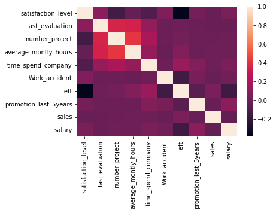

```python
#Correlation Matrix
corr = df.corr()
corr = (corr)
sns.heatmap(corr,
 xticklabels=corr.columns.values,
 yticklabels=corr.columns.values)
corr
```

# Analyze by binary relationship table

```python
df[['left', 'satisfaction_level']].groupby(['left'],
as_index=False).mean().sort_values(by='satisfaction_level',
ascending=False)
```

|  | left | satisfaction_level |
| --- | --- | --- |
| 0 | 0 | 0.666810 |
| 1 | 1 | 0.440098 |

Here those who had work accident actually have 0.1 higher possibility to stay in the company, which is counter intuitive. This is the time when Machine Learning comes into play, to discover underlying relationship that does not make sense with normal ways of anaylysis.

```python
df[['left', 'Work_accident']].groupby(['left'],
as_index=False).mean().sort_values(by='Work_accident',
ascending=False)
```

|  | left | Work_accident |
| --- | --- | --- |
| 0 | 0 | 0.175009 |
| 1 | 1 | 0.047326 |

When grouped by "left" factor, the data of time_spend_company is not very helpful. Therefore we try to group by time_spend_company as below. We see those who spent 3-6 years at the company are most likely to leave.

```python
df[['left', 'time_spend_company']].groupby(['time_spend_company'],
as_index=False).mean().sort_values(by='left', ascending=False)
```

|  | time_spend_company | left |
| --- | --- | --- |
| 3 | 5 | 0.565513 |
| 2 | 4 | 0.348064 |
| 4 | 6 | 0.291086 |
| 1 | 3 | 0.246159 |
| 0 | 2 | 0.016338 |
| 5 | 7 | 0.000000 |
| 6 | 8 | 0.000000 |
| 7 | 10 | 0.000000 |

The salary factor shows these who left are those who earns the least.

```python
df[['left', 'salary']].groupby(['salary'],
as_index=False).mean().sort_values(by='left', ascending=False)
```

|  | salary | left |
| --- | --- | --- |
| 0 | 0 | 0.296884 |
| 1 | 1 | 0.204313 |
| 2 | 2 | 0.066289 |

Visualize and convert continuous data to discrete Other than the corerlation with binary "left" factor, exploring correlation between other factors can also give us very constructive information,

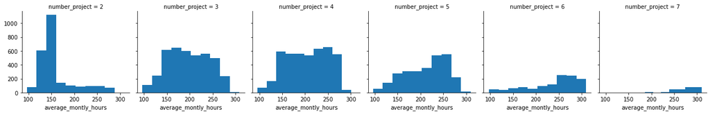

```python
g = sns.FacetGrid(df, col='number_project')
g.map(plt.hist, 'average_montly_hours', bins=10)
```

We see a positive relationship between number of project with average monthly hours. Therefore we can combine these two columns. By either dropping one of them or multiply them to make correlation even stronger.

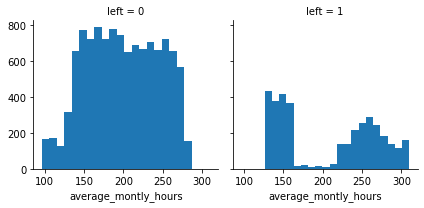

```python
g = sns.FacetGrid(df, col='left')
g.map(plt.hist, 'average_montly_hours', bins=20)
```

We can see that those who work less than about 160 hours and more than about 270 hours are more likely to leave, but for some reason it significantly lower the accuracy when trying to convert this average hour into discreet representation, so we keep it as it for now.

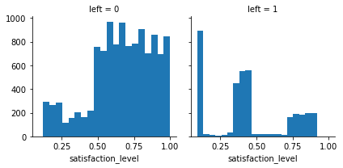

```python
g = sns.FacetGrid(df, col='left')
g.map(plt.hist, 'satisfaction_level', bins=20)
```

The relationship of satisfaction_level and left are also bimodially correlated. Since the correlation of "satisfaction_level" with "left" is 0.39 which is pretty high, it is worth modifying the data to better reflect how each satisfaction_level range influence the "left".

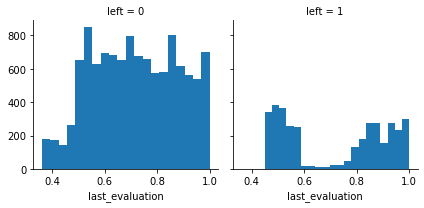

```python
#From the above graph, we see a high left rate between 0.25-0.5 and also >0.75
df.loc[ df['satisfaction_level'] <= 0.25, 'satisfaction_level'] = 0
df.loc[(df['satisfaction_level'] > 0.25) & (df['satisfaction_level']
<= 0.5), 'satisfaction_level'] = 1
df.loc[(df['satisfaction_level'] > 0.5) & (df['satisfaction_level'] <=
0.75), 'satisfaction_level'] = 0
df.loc[ df['satisfaction_level'] > 0.75, 'satisfaction_level'] = 1
df['satisfaction_level'] = df['satisfaction_level'].astype(int)
g = sns.FacetGrid(df, col='left')
g.map(plt.hist, 'last_evaluation', bins=20)
```

The last_evaluation also has a clear pattern for those who choose to leave the company. We see from above that if one's last_evaluation is <0.56 or >0.8, one has higher tendency to leave the company.

```python
df.loc[ df['last_evaluation'] <= 0.56, 'last_evaluation'] = 0
df.loc[(df['last_evaluation'] > 0.56) & (df['last_evaluation'] <=
0.80), 'last_evaluation'] = 1
df.loc[ df['last_evaluation'] > 0.80, 'last_evaluation'] = 0
df['last_evaluation'] = df['last_evaluation'].astype(int)
```

# Create new column from existing data

We see from the previous correlation matrix analysis that 'number_project' and 'average_montly_hours' are strongly correlated, therefore we can combine these existing columns to create new feature.

```python
df["proj*hour"] = df.number_project * df.average_montly_hours
df.loc[:,
['proj*hour','number_project','average_montly_hours']].head(10)
```

|  | proj*hour | number_project | average_montly_hours |
| --- | --- | --- | --- |
| 0 | 314 | 2 | 157 |
| 1 | 1310 | 5 | 262 |
| 2 | 1904 | 7 | 272 |
| 3 | 1115 | 5 | 223 |
| 4 | 318 | 2 | 159 |
| 5 | 306 | 2 | 153 |
| 6 | 1482 | 6 | 247 |
| 7 | 1295 | 5 | 259 |
| 8 | 1120 | 5 | 224 |
| 9 | 284 | 2 | 142 |

# Remove duplicate datasets

Since we have 'proj*hour' now, we can drop 'number_project' and 'average_montly_hours' to remove duplicate data from model

```python
df = df.drop(['number_project','average_montly_hours'], axis=1)
```

Split train and test datsets Now we can split the preprocessed data to training dataset and testing dataset, which are 85% and 15% of the original dataset

```python
nHead = int(len(df)*0.85)
nTail = int(len(df)*0.15)
X_train = df.drop("left", axis=1).head(nHead)
X_test = df.drop("left", axis=1).tail(nTail)
Y_train = df["left"].head(nHead)
Y_test = df["left"].tail(nTail)
X_train.shape, X_test.shape
```

```
((12749, 8), (2249, 8))
```

# Modeling with dataset

There are several modeling strategies. Here we list three distinct ones and test out which one works best.

# Support Vector Machines

support vector machines (SVMs, also support vector networks[1]) are supervised learning models with associated learning algorithms that analyze data used for classification and regression analysis. Given a set of training examples, each marked as belonging to one or the other of two categories, an SVM training algorithm builds a model that assigns newexamples to one category or the other.

```python
svc = SVC()
svc.fit(X_train, Y_train)
acc_svc = round(svc.score(X_test, Y_test) * 100, 2)
acc_svc
```

```
84.62
```

k-nearest neighbors k-nearest neighbors algorithm (k-NN) is a non-parametricmethod used for classification and regression.[1] In both cases, the input consists of the k closest training examples in the feature space.

```python
knn = KNeighborsClassifier(n_neighbors = 3)
knn.fit(X_train, Y_train)
acc_knn = round(knn.score(X_test, Y_test) * 100, 2)
acc_knn
```

```
95.86
```

# decision tree

A decision tree is a decision support tool that uses a tree-like graph or model of decisions and their possible consequences, including chance event outcomes, resource costs, and utility. It is one way to display an algorithm that only contains conditional control statements.

```python
# Decision Tree
decision_tree = DecisionTreeClassifier()
decision_tree.fit(X_train, Y_train)
acc_decision_tree = round(decision_tree.score(X_test, Y_test) * 100,
2)
acc_decision_tree
```

```
99.64
```